# Framework de software I

Nome: Ricardo Del Trejo R.A.: 5771601055

## Título do Dataset: Glass Identification Database

Link para descrição do Dataset: [UCI Machine Learning Repository](https://archive.ics.uci.edu/ml/machine-learning-databases/glass/glass.names)

## Descrição do problema

Foi necessário a classificação dos vidros em "float" ou não, esta classificação tornou-se necessária devido a uma investigação criminal onde a correta identificação torna um vidro como evidência do caso ou não.

O processo float surgiu nos anos de 1950 e trata-se de fazer com que o vidro ainda não derretido flutue por estanho derretido, este tipo de vidro é indicado para vidros planos, fazendo com que tenham excelente uniformidade e não possuem quase nenhuma distorção óptica.

[figure not shown]

*Diferenças entre vidro sem o processo float(acima) com aquele que passou pelo processo(abaixo)*

## Exploração dos dados

1. Id number: Número de identificação do vidro, vai de 1 a 214. Será desconsiderado do modelo pois não influencia no resultado por ser apenas um identificar
2. RI: índice de refração
3. Na: Sódio (unidade de medida é a porcentagem em peso no óxido correspondente, assim como os atributos 4-10)
4. Mg: Magnésio
5. Al: Alumínio
6. Si: Silício
7. K: Potássio
8. Ca: Cálcio
9. Ba: Bário
10. Fe: Ferro
11. Type of glass: Atributo do vidro, vai de 1 a 7 sendo:
    - 1. building_windows_float_processed
    - 2. building_windows_non_float_processed
    - 3. vehicle_windows_float_processed
    - 4. vehicle_windows_non_float_processed (inexistente nesta base)
    - 5. containers
    - 6. tableware
    - 7. headlamps

# Gráficos

```python
import pandas as pd
```

```python
lista_colunas = ["Id","RI","Na","Mg","Al","Si","K","Ca","Ba", "Fe", "Type"]
df = pd.read_csv("https://archive.ics.uci.edu/ml/machine-learning-databases/glass/glass.data", names = lista_colunas)
X = df.drop("Type", axis = 1)
y = df["Type"]
```

```python
import matplotlib.pyplot as plt
%matplotlib inline
```

[output not shown]

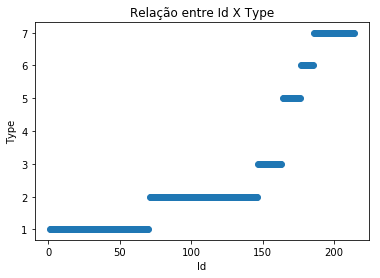

```python
plt.scatter(df.Id, y)
plt.xlabel("Id")
plt.ylabel("Type")
plt.title("Relação entre Id X Type")
plt.show
```

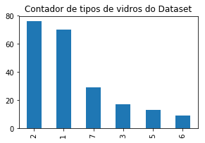

```python
fig = plt.figure(figsize=(10,10))
fig_dims = (3, 2)
plt.subplot2grid(fig_dims, (0, 0))
df['Type'].value_counts().plot(kind='bar', title='Contador de tipos de vidros do Dataset')
```

# Aplicação de Machine Learn

```python
from sklearn import metrics
```

## Usando o SVM

```python
from sklearn.svm import SVC
```

```python
svm = SVC()
```

```python
svm.fit(X, y)
```

```
SVC(C=1.0, cache_size=200, class_weight=None, coef0=0.0,
  decision_function_shape=None, degree=3, gamma='auto', kernel='rbf',
  max_iter=-1, probability=False, random_state=None, shrinking=True,
  tol=0.001, verbose=False)
```

```python
y_svm = svm.predict(X)
acuSvm = metrics.accuracy_score(y,y_svm)
kaSvm = metrics.cohen_kappa_score(y,y_svm)
```

## Usando KNN com k variando de 1 a 29

```python
from sklearn.neighbors import KNeighborsClassifier
```

```python
k_range = list(range(1,30))
```

```python
list_acuracia = []
list_kappa = []
for k in k_range:
    knn = KNeighborsClassifier(n_neighbors = k)
    knn.fit(X,y)
    y_pred = knn.predict(X)
    acu = metrics.accuracy_score(y,y_pred)
    list_acuracia.append(acu)
    ka = metrics.cohen_kappa_score(y,y_pred)
    list_kappa.append(ka)
```

```python
#acurária svm
acuSvm
```

```
1.0
```

```python
#Cohen’s kappa svm
kaSvm
```

```
1.0
```

```python
#acurária knn
list_acuracia
```

```
[1.0,
 0.99532710280373837,
 0.99532710280373837,
 0.99532710280373837,
 0.99532710280373837,
 0.99065420560747663,
 0.99065420560747663,
 0.99532710280373837,
 0.99532710280373837,
 0.99065420560747663,
 0.99065420560747663,
 0.99065420560747663,
 0.99065420560747663,
 0.99065420560747663,
 0.99065420560747663,
 0.98598130841121501,
 0.99065420560747663,
 0.98130841121495327,
 0.99065420560747663,
 0.98130841121495327,
 0.98598130841121501,
 0.96728971962616828,
 0.9719626168224299,
 0.96261682242990654,
 0.96261682242990654,
 0.95794392523364491,
 0.95327102803738317,
 0.94859813084112155,
 0.94392523364485981]
```

```python
#Cohen’s kappa knn
list_kappa
```

```
[1.0,
 0.99365662793455067,
 0.99365662793455067,
 0.99365662793455067,
 0.99365662793455067,
 0.98729102948599934,
 0.98731475992886786,
 0.99365662793455067,
 0.99365662793455067,
 0.98729102948599934,
 0.98731475992886786,
 0.98732077260338902,
 0.98731475992886786,
 0.98732077260338902,
 0.98731475992886786,
 0.98096537001897532,
 0.98731175145262662,
 0.97464304757390841,
 0.98730573021710766,
 0.97461296636811201,
 0.98095633602278121,
 0.9554630593132154,
 0.96186289651894974,
 0.94905520011902988,
 0.94913844325609031,
 0.94274673008323429,
 0.93637769056962772,
 0.92985906260242546,
 0.9237778635243834]
```